FJ

# Feidhelm Joyce

Business & Data Analyst  
Boston, MA

linkedin.com/in/feidhelmjoyce  
github.com/FeidhelmJ

HomeProfessional SummaryMarketing AnalyticsFinancial AnalyticsData Mining for Business AnalyticsCloud AnalyticsProjectsSkillsContact

FINANCIAL ANALYTICS

## Bubbles: Dot-Com & Mortgage Credit

← Back to Financial Analytics

```
import numpy as np
import pandas as pd
import matplotlib.pyplot as plt
import seaborn as sns
```

# PART A – The Dot-Com Boom

```
dotcom_cont = pd.read_csv('dotcom_cont.csv')
```

# Qualitative context quotes

```
dotcom_cont.info()
```

```
<class 'pandas.core.frame.DataFrame'>
RangeIndex: 7 entries, 0 to 6
Data columns (total 2 columns):
 #   Column   Non-Null Count  Dtype
---  ------   --------------  -----
 0   date     7 non-null      object
 1   excerpt  7 non-null      object
dtypes: object(2)
memory usage: 244.0+ bytes
```

```
pd.set_option('display.max_colwidth', None)
```

```
dotcom_cont.head(10)
```

|  | date | excerpt |
| --- | --- | --- |
| 0 | 1998-09-01 | Internet adoption is accelerating; profitability can come later once scale is achieved. |
| 1 | 1999-02-01 | Online brokerages are making markets feel accessible to everyone. |
| 2 | 1999-08-01 | Network effects justify premium multiples for category leaders. |
| 3 | 1999-12-01 | Traditional metrics may not capture intangible value. |
| 4 | 2000-03-01 | A shift in rates could reprice long-duration growth quickly. |
| 5 | 2000-10-01 | Liquidity is thinner than it appears when sentiment turns. |
| 6 | 2001-03-01 | Survivors are cutting burn and focusing on unit economics. |

# Cross-sectional firm snapshot

```
fund = pd.read_csv('dotcom_fundamentals.csv')
```

```
fund.head(10)
```

|  | firm_id | sector | revenue_1999_mil_usd | revenue_growth_1999_pct | net_margin_1999_pct | price_to_sales_1999 | price_to_earnings_1999 | market_cap_1999_mil_usd | cash_on_hand_mil_usd | annual_cash_burn_mil_usd |
| --- | --- | --- | --- | --- | --- | --- | --- | --- | --- | --- |
| 0 | DC001 | Semiconductors | 114.2 | 82.1 | 30.5 | 6.39 | 12.7 | 729.5 | 66.5 | 0.0 |
| 1 | DC002 | Internet/Software | 36.9 | 92.9 | -6.2 | 39.10 | NaN | 1441.9 | 362.0 | 2.2 |
| 2 | DC003 | Semiconductors | 326.6 | 93.1 | -11.2 | 12.78 | NaN | 4171.8 | 160.9 | 24.1 |
| 3 | DC004 | Telecom | 164.7 | 43.4 | 35.0 | 11.63 | 81.8 | 1915.7 | 33.7 | 0.0 |
| 4 | DC005 | Networking | 63.6 | 96.9 | -39.9 | 9.09 | NaN | 577.8 | 54.7 | 24.1 |
| 5 | DC006 | Semiconductors | 20.5 | 90.1 | 35.0 | 3.77 | 27.0 | 77.2 | 24.7 | 0.0 |
| 6 | DC007 | Enterprise SaaS | 91.5 | 84.5 | 12.6 | 5.35 | 59.8 | 489.0 | 132.6 | 0.0 |
| 7 | DC008 | Networking | 106.8 | 147.4 | 16.1 | 17.27 | 41.3 | 1844.6 | 48.1 | 0.0 |
| 8 | DC009 | Enterprise SaaS | 45.6 | 93.0 | 10.2 | 24.98 | 43.2 | 1138.7 | 72.1 | 0.0 |
| 9 | DC010 | Semiconductors | 60.5 | 124.5 | -2.5 | 20.09 | NaN | 1214.9 | 253.5 | 1.8 |

```
fund['sector'].value_counts()
```

| sector | count |
| --- | --- |
| Semiconductors | 16 |
| Internet/Software | 11 |
| E-commerce | 11 |
| Telecom | 9 |
| Networking | 7 |
| Enterprise SaaS | 6 |

```
fund.info()
```

```
<class 'pandas.core.frame.DataFrame'>
RangeIndex: 60 entries, 0 to 59
Data columns (total 10 columns):
 #   Column                    Non-Null Count  Dtype
---  ------                    --------------  -----
 0   firm_id                   60 non-null     object
 1   sector                    60 non-null     object
 2   revenue_1999_mil_usd      60 non-null     float64
 3   revenue_growth_1999_pct   60 non-null     float64
 4   net_margin_1999_pct       60 non-null     float64
 5   price_to_sales_1999       60 non-null     float64
 6   price_to_earnings_1999    20 non-null     float64
 7   market_cap_1999_mil_usd   60 non-null     float64
 8   cash_on_hand_mil_usd      60 non-null     float64
 9   annual_cash_burn_mil_usd  60 non-null     float64
dtypes: float64(8), object(2)
memory usage: 4.8+ KB
```

```
fund.describe()
```

|  | revenue_1999_mil_usd | revenue_growth_1999_pct | net_margin_1999_pct | price_to_sales_1999 | price_to_earnings_1999 | market_cap_1999_mil_usd | cash_on_hand_mil_usd | annual_cash_burn_mil_usd |
| --- | --- | --- | --- | --- | --- | --- | --- | --- |
| count | 60.000000 | 60.000000 | 60.000000 | 60.000000 | 20.000000 | 60.000000 | 60.000000 | 60.000000 |
| mean | 111.313333 | 89.815000 | -11.156667 | 23.066167 | 49.940000 | 2737.951667 | 97.736667 | 14.048333 |
| std | 100.309637 | 35.667223 | 25.039605 | 17.319176 | 26.417825 | 4721.219616 | 102.297227 | 19.009672 |
| min | 13.700000 | 20.400000 | -72.300000 | 3.310000 | 12.700000 | 77.200000 | 6.600000 | 0.000000 |
| 25% | 41.975000 | 70.000000 | -29.050000 | 11.610000 | 33.300000 | 735.725000 | 28.575000 | 0.000000 |
| 50% | 82.750000 | 84.900000 | -6.150000 | 17.850000 | 45.000000 | 1342.150000 | 60.150000 | 6.000000 |
| 75% | 131.850000 | 103.850000 | 6.625000 | 28.775000 | 70.550000 | 2940.800000 | 124.275000 | 18.200000 |
| max | 509.300000 | 179.900000 | 35.000000 | 80.000000 | 93.400000 | 31622.400000 | 480.700000 | 66.300000 |

# IPO counts and VC inflows

```
ipo_vc = pd.read_csv('dotcom_ipo.csv')
```

```
ipo_vc.head(10)
```

|  | month | tech_ipo_count | vc_inflows_bil_usd |
| --- | --- | --- | --- |
| 0 | 1998-01-01 | 17 | 4.03 |
| 1 | 1998-02-01 | 18 | 4.89 |
| 2 | 1998-03-01 | 25 | 3.44 |
| 3 | 1998-04-01 | 15 | 5.40 |
| 4 | 1998-05-01 | 19 | 4.71 |
| 5 | 1998-06-01 | 22 | 5.16 |
| 6 | 1998-07-01 | 18 | 4.14 |
| 7 | 1998-08-01 | 26 | 6.80 |
| 8 | 1998-09-01 | 24 | 7.58 |
| 9 | 1998-10-01 | 20 | 7.40 |

```
ipo_vc.tail(24)
```

|  | month | tech_ipo_count | vc_inflows_bil_usd |
| --- | --- | --- | --- |
| 24 | 2000-01-01 | 65 | 19.67 |
| 25 | 2000-02-01 | 67 | 19.51 |
| 26 | 2000-03-01 | 69 | 22.74 |
| 27 | 2000-04-01 | 66 | 21.39 |
| 28 | 2000-05-01 | 65 | 20.53 |
| 29 | 2000-06-01 | 71 | 20.24 |
| 30 | 2000-07-01 | 54 | 20.35 |
| 31 | 2000-08-01 | 59 | 19.23 |
| 32 | 2000-09-01 | 60 | 18.28 |
| 33 | 2000-10-01 | 60 | 18.13 |
| 34 | 2000-11-01 | 53 | 19.29 |
| 35 | 2000-12-01 | 53 | 14.66 |
| 36 | 2001-01-01 | 52 | 17.01 |
| 37 | 2001-02-01 | 45 | 15.88 |
| 38 | 2001-03-01 | 41 | 15.42 |
| 39 | 2001-04-01 | 48 | 16.63 |
| 40 | 2001-05-01 | 39 | 13.92 |
| 41 | 2001-06-01 | 34 | 14.16 |
| 42 | 2001-07-01 | 36 | 12.57 |
| 43 | 2001-08-01 | 33 | 12.47 |
| 44 | 2001-09-01 | 28 | 12.55 |
| 45 | 2001-10-01 | 26 | 9.99 |
| 46 | 2001-11-01 | 34 | 10.77 |
| 47 | 2001-12-01 | 26 | 9.46 |

```
ipo_vc.info()
```

```
<class 'pandas.core.frame.DataFrame'>
RangeIndex: 48 entries, 0 to 47
Data columns (total 3 columns):
 #   Column              Non-Null Count  Dtype
---  ------              --------------  -----
 0   month               48 non-null     object
 1   tech_ipo_count      48 non-null     int64
 2   vc_inflows_bil_usd  48 non-null     float64
dtypes: float64(1), int64(1), object(1)
memory usage: 1.3+ KB
```

```
ipo_vc.describe()
```

|  | tech_ipo_count | vc_inflows_bil_usd |
| --- | --- | --- |
| count | 48.000000 | 48.000000 |
| mean | 40.166667 | 12.933542 |
| std | 16.442464 | 5.463526 |
| min | 15.000000 | 3.440000 |
| 25% | 26.000000 | 8.417500 |
| 50% | 37.000000 | 12.560000 |
| 75% | 53.000000 | 17.897500 |
| max | 71.000000 | 22.740000 |

# Macro and market indicators

```
market = pd.read_csv('dotcom_market.csv')
```

```
market.head(10)
```

|  | month | nasdaq_index_level | fed_funds_rate_pct | tech_ipo_count | vc_inflows_bil_usd | median_price_to_sales | share_unprofitable_recent_ipos | retail_participation_proxy | margin_debt_index |
| --- | --- | --- | --- | --- | --- | --- | --- | --- | --- |
| 0 | 1998-01-01 | 1849 | 5.50 | 13 | 3.49 | 7.57 | 0.510 | 0.222 | 60.2 |
| 1 | 1998-02-01 | 1891 | 5.70 | 15 | 4.93 | 7.16 | 0.424 | 0.209 | 64.2 |
| 2 | 1998-03-01 | 2081 | 5.66 | 21 | 4.16 | 6.36 | 0.467 | 0.222 | 56.3 |
| 3 | 1998-04-01 | 1949 | 5.95 | 15 | 5.24 | 7.76 | 0.450 | 0.225 | 66.9 |
| 4 | 1998-05-01 | 2105 | 5.96 | 19 | 5.10 | 6.13 | 0.535 | 0.258 | 70.1 |
| 5 | 1998-06-01 | 2220 | 6.07 | 24 | 5.34 | 8.63 | 0.489 | 0.228 | 68.6 |
| 6 | 1998-07-01 | 2223 | 6.02 | 24 | 6.39 | 6.05 | 0.562 | 0.245 | 63.8 |
| 7 | 1998-08-01 | 2465 | 6.32 | 19 | 5.23 | 7.65 | 0.485 | 0.273 | 74.6 |
| 8 | 1998-09-01 | 2503 | 6.41 | 27 | 7.65 | 7.98 | 0.533 | 0.275 | 79.5 |
| 9 | 1998-10-01 | 2495 | 6.39 | 28 | 6.50 | 8.27 | 0.574 | 0.270 | 75.3 |

```
market.info()
```

```
<class 'pandas.core.frame.DataFrame'>
RangeIndex: 48 entries, 0 to 47
Data columns (total 9 columns):
 #   Column                          Non-Null Count  Dtype
---  ------                          --------------  -----
 0   month                           48 non-null     object
 1   nasdaq_index_level              48 non-null     int64
 2   fed_funds_rate_pct              48 non-null     float64
 3   tech_ipo_count                  48 non-null     int64
 4   vc_inflows_bil_usd              48 non-null     float64
 5   median_price_to_sales           48 non-null     float64
 6   share_unprofitable_recent_ipos  48 non-null     float64
 7   retail_participation_proxy      48 non-null     float64
 8   margin_debt_index               48 non-null     float64
dtypes: float64(6), int64(2), object(1)
memory usage: 3.5+ KB
```

```
market.describe()
```

|  | nasdaq_index_level | fed_funds_rate_pct | tech_ipo_count | vc_inflows_bil_usd | median_price_to_sales | share_unprofitable_recent_ipos | retail_participation_proxy | margin_debt_index |
| --- | --- | --- | --- | --- | --- | --- | --- | --- |
| count | 48.000000 | 48.000000 | 48.000000 | 48.000000 | 48.000000 | 48.000000 | 48.000000 | 48.00000 |
| mean | 3471.812500 | 6.102292 | 40.083333 | 12.960208 | 14.951875 | 0.666229 | 0.390375 | 121.51875 |
| std | 927.477055 | 0.218518 | 16.171729 | 5.405339 | 5.530911 | 0.102069 | 0.094806 | 37.11019 |
| min | 1849.000000 | 5.500000 | 13.000000 | 3.490000 | 6.050000 | 0.424000 | 0.209000 | 56.30000 |
| 25% | 2718.750000 | 5.957500 | 28.000000 | 8.122500 | 9.730000 | 0.598000 | 0.310500 | 89.82500 |
| 50% | 3461.000000 | 6.125000 | 36.000000 | 13.880000 | 15.290000 | 0.691500 | 0.419000 | 124.45000 |
| 75% | 4232.000000 | 6.265000 | 55.000000 | 17.437500 | 19.837500 | 0.741000 | 0.454750 | 155.40000 |
| max | 4984.000000 | 6.470000 | 75.000000 | 22.220000 | 23.740000 | 0.824000 | 0.520000 | 180.20000 |

## A1 – Recommendation (≤ 200 words)

Should a long-term institutional investor allocate capital to this sector at this time?

Choose one:

• Overweight

• Market Weight

• Underweight

• Avoid

## Recommendation: Underweight

A long-term institutional investor should adopt an underweight position in the dot-com sector as of late 1999. While the data shows strong revenue expansion with an average growth of 89.8%, profitability is weak with 66.7% of firms being unprofitable and the average net margin is –11.2%. Despite this, valuations are stretched, with a mean price-to-sales ratio of 23x and a December 1999 median sector multiple of 20.9x.

Capital market conditions further indicate elevated risk. In December 1999 alone, 62 tech IPOs came to market and venture capital inflows reached $17.82 billion. Notably, as of December 1999, 72% of recent IPOs remain unprofitable. Margin debt levels with an index of 160.7 and retail participation of 0.48 suggest rising speculative engagement.

Although the internet represents a genuine structural innovation with long-term transformative potential, current market conditions warrant caution. The sector is characterized by widespread unprofitability, elevated valuation multiples, heavy IPO issuance, and rising leverage, all of which increase vulnerability to a drop in investor confidence or tightening financial conditions. These dynamics create an unfavorable risk-return profile, with limited upside relative to potential losses. A disciplined long-term institutional investor should therefore maintain exposure to structurally advantaged, higher-quality firms while reducing overall allocation relative to benchmark weight to better manage risk at this stage of the cycle.

```
avg_revenue_growth = fund["revenue_growth_1999_pct"].mean()
```

```
pct_unprofitable = (fund["net_margin_1999_pct"] < 0).mean() * 100
```

```
avg_net_margin = fund["net_margin_1999_pct"].mean()
```

```
mean_ps = fund["price_to_sales_1999"].mean()
```

```
print(f"Average revenue growth: {avg_revenue_growth:.1f}%")
print(f"% unprofitable firms: {pct_unprofitable:.1f}%")
print(f"Average net margin: {avg_net_margin:.1f}%")
print(f"Mean price-to-sales ratio: {mean_ps:.1f}x")
```

```
Average revenue growth: 89.8%
% unprofitable firms: 66.7%
Average net margin: -11.2%
Mean price-to-sales ratio: 23.1x
```

```
market["month"] = pd.to_datetime(market["month"])
```

```
dec_1999 = market[market["month"] == "1999-12-01"]
```

```
median_ps_dec_1999 = dec_1999["median_price_to_sales"].values[0]
```

```
print(f"December 1999 median sector P/S: {median_ps_dec_1999:.1f}x")
```

```
December 1999 median sector P/S: 20.9x
```

```
ipo_vc["month"] = pd.to_datetime(ipo_vc["month"])
```

```
cutoff = pd.to_datetime("1999-12-01")
```

```
ipo_vc_dec_1999 = ipo_vc.loc[ipo_vc["month"] == cutoff].iloc[0]
```

```
tech_ipos_dec_1999 = ipo_vc_dec_1999["tech_ipo_count"]
vc_inflows_dec_1999 = ipo_vc_dec_1999["vc_inflows_bil_usd"]
```

```
market_dec_1999 = market.loc[market["month"] == cutoff].iloc[0]
```

```
share_unprof_recent_ipos_dec_1999 = market_dec_1999["share_unprofitable_recent_ipos"]
margin_debt_index_dec_1999 = market_dec_1999["margin_debt_index"]
retail_participation_dec_1999 = market_dec_1999["retail_participation_proxy"]
```

```
print(f"Tech IPOs in Dec 1999: {tech_ipos_dec_1999}")
print(f"VC inflows in Dec 1999: ${vc_inflows_dec_1999:.2f}B")
print(f"Share unprofitable recent IPOs (Dec 1999): {share_unprof_recent_ipos_dec_1999:.2%}")
print(f"Margin debt index (Dec 1999): {margin_debt_index_dec_1999:.1f}")
print(f"Retail participation proxy (Dec 1999): {retail_participation_dec_1999:.2f}")
```

```
Tech IPOs in Dec 1999: 62
VC inflows in Dec 1999: $17.82B
Share unprofitable recent IPOs (Dec 1999): 72.00%
Margin debt index (Dec 1999): 160.7
Retail participation proxy (Dec 1999): 0.48
```

# A2 – Evidence (Required visuals + table)

```
ipo_vc_1999 = ipo_vc[ipo_vc["month"] <= cutoff].copy()
market_1999 = market[market["month"] <= cutoff].copy()
```

```
plt.figure(figsize=(10, 5))
plt.plot(ipo_vc_1999["month"], ipo_vc_1999["tech_ipo_count"], marker="o")
plt.title("Figure 1. Monthly Technology IPO Count (1998–Dec 1999)")
plt.xlabel("Month")
plt.ylabel("Tech IPO Count")
plt.grid(True, alpha=0.3)
plt.tight_layout()
plt.show()
```

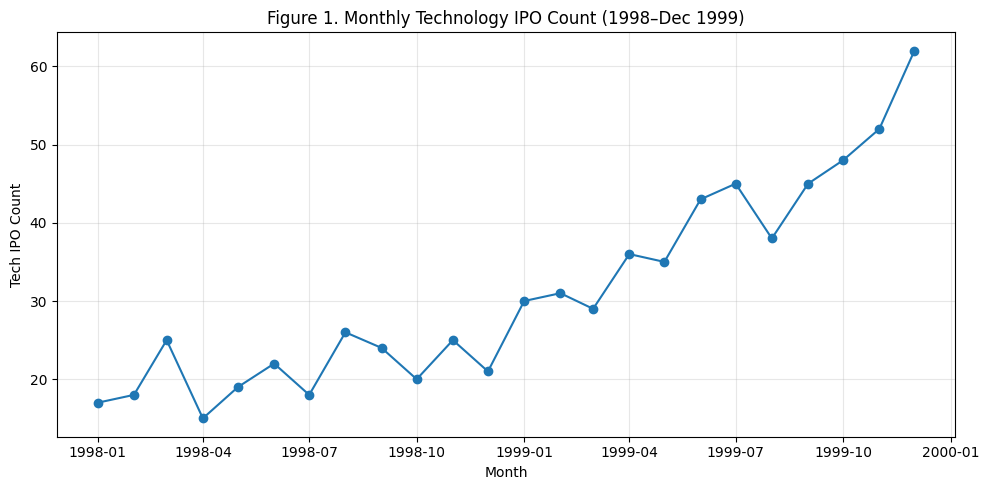

The above time series graph illustrates the steady acceleration in monthly technology IPO issuance from early 1998 through December 1999. IPO counts rise from the mid-teens in early 1998 to 62 offerings in December 1999, reflecting a sharp expansion in capital market activity. The upward trajectory suggests increasing investor demand and a growing willingness of firms to enter public markets at elevated valuations. This sharp increase in IPO activity is typical of periods when markets become increasingly enthusiastic and money is readily available. As confidence grows, more companies rush to go public, often at high valuations. While this reflects strong demand, it can also suggest that the market is becoming overly optimistic. When activity accelerates this quickly, it may indicate that expectations have moved ahead of fundamentals. This environment supports an underweight recommendation, as markets driven by strong enthusiasm can be more vulnerable if investor confidence begins to weaken.

```
margins = fund["net_margin_1999_pct"].dropna()
mean_margin = margins.mean()
median_margin = margins.median()
```

```
plt.figure(figsize=(10, 5))
plt.hist(margins, bins=14, edgecolor="white", alpha=0.9)
plt.axvline(0, linewidth=2, linestyle="--", alpha=0.8)
plt.axvline(mean_margin, linewidth=2, linestyle=":", alpha=0.9)
plt.axvline(median_margin, linewidth=2, linestyle="-.", alpha=0.9)
plt.title("Figure 2. Distribution of Firm Net Margins (1999)")
plt.xlabel("Net Margin (%)")
plt.ylabel("Number of Firms")
text = (
    f"Mean: {mean_margin:.1f}%\n"
    f"Median: {median_margin:.1f}%\n"
    f"% Unprofitable: {(margins < 0).mean()*100:.1f}%"
)
plt.gca().text(
    0.98, 0.95, text,
    transform=plt.gca().transAxes,
    ha="right", va="top",
    bbox=dict(boxstyle="round,pad=0.3", alpha=0.15)
)
plt.grid(True, axis="y", alpha=0.25)
plt.tight_layout()
plt.show()
```

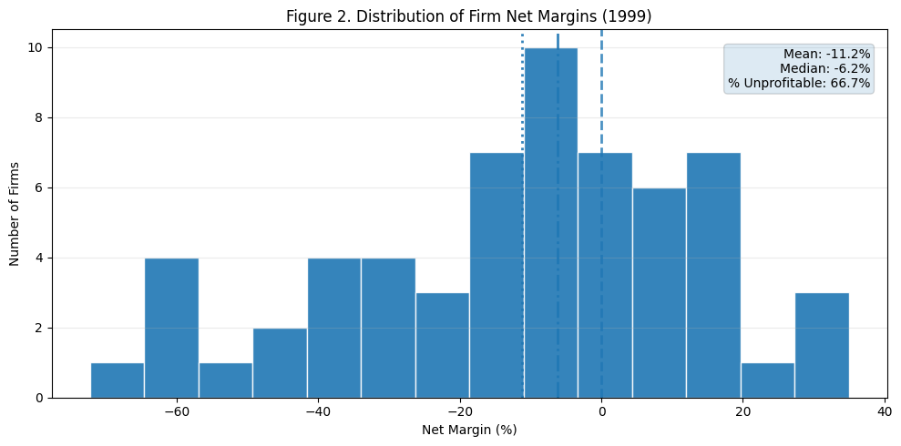

The histogram above shows the distribution of firm net margins in 1999, highlighting how profitable (or unprofitable) the typical dot-com firm was at the time. Most observations fall below 0%, meaning many companies were losing money rather than generating sustainable earnings. The chart also shows a noticeable left tail, with several firms reporting very large losses, while only a smaller share achieved positive margins. The key takeaway is that profitability was the exception, not the norm. This supports an underweight recommendation because when a sector is dominated by loss-making firms, valuations depend heavily on continued optimism and future growth expectations.

```
x = fund["revenue_growth_1999_pct"]
y = fund["price_to_sales_1999"]
plt.figure(figsize=(10, 6))
plt.scatter(x, y, alpha=0.7)


plt.title("Figure 3. Revenue Growth vs Price-to-Sales (1999)")
plt.xlabel("Revenue Growth (1999, %)")
plt.ylabel("Price-to-Sales (1999, x)")
plt.grid(True, alpha=0.25)
plt.tight_layout()
plt.show()
```

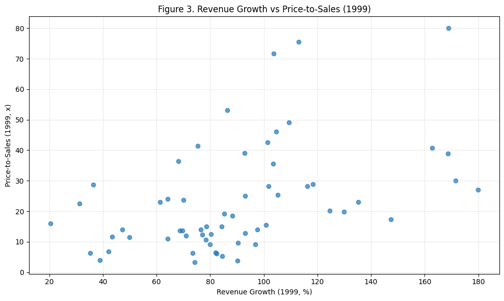

The above graph plots firm-level revenue growth against price-to-sales multiples in 1999, illustrating how companies were valued relative to their expansion rates. While many firms demonstrate strong revenue growth—often above 80%—valuation multiples remain elevated across the sample, with several firms trading at 40x sales or higher. Importantly, high valuations are not limited to the fastest-growing firms, suggesting that pricing reflects broad optimism rather than purely fundamentals. The key takeaway is that growth alone does not fully explain valuation levels. This supports an underweight recommendation, as stretched multiples across the sector reduce the margin of safety for long-term investors.

```
profit_flag = (fund["net_margin_1999_pct"] >= 0).map({True: "Profitable", False: "Unprofitable"})
counts = profit_flag.value_counts().reindex(["Profitable", "Unprofitable"])

plt.figure(figsize=(8, 5))
plt.bar(counts.index, counts.values)
plt.title("Figure 4. Profitability Composition of Firms (1999)")
plt.xlabel("Profitability Status")
plt.ylabel("Number of Firms")
plt.grid(True, axis="y", alpha=0.3)
plt.tight_layout()
plt.show()
```

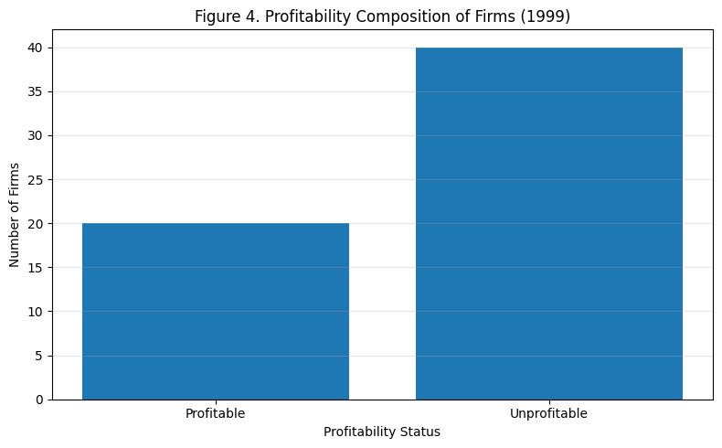

The bar chart above compares the number of profitable and unprofitable firms in the 1999 sample. The chart shows that unprofitable firms significantly outnumber profitable ones, with roughly two-thirds of companies reporting negative net margins. This highlights that losses were widespread across the sector, rather than isolated to a small subset of firms. The key takeaway is that profitability was not yet established at a broad industry level, despite strong revenue growth. This imbalance supports an underweight recommendation, as a sector dominated by loss-making firms may be particularly vulnerable if investor expectations begin to moderate.

```
avg_rev_growth = fund["revenue_growth_1999_pct"].mean()
pct_unprofitable = (fund["net_margin_1999_pct"] < 0).mean() * 100
avg_net_margin = fund["net_margin_1999_pct"].mean()
mean_ps = fund["price_to_sales_1999"].mean()
```

```
dec_market = market_1999.loc[market_1999["month"] == cutoff].iloc[0]
median_ps_dec = dec_market["median_price_to_sales"]
share_unprof_recent_ipos = dec_market["share_unprofitable_recent_ipos"] * 100
margin_debt_index = dec_market["margin_debt_index"]
retail_participation = dec_market["retail_participation_proxy"]
```

```
dec_ipo_vc = ipo_vc_1999.loc[ipo_vc_1999["month"] == cutoff].iloc[0]
tech_ipos_dec = dec_ipo_vc["tech_ipo_count"]
vc_inflows_dec = dec_ipo_vc["vc_inflows_bil_usd"]
```

```
table_1 = pd.DataFrame({
    "Indicator": [
        "Average Revenue Growth (1999)",
        "% Unprofitable Firms (1999)",
        "Average Net Margin (1999)",
        "Mean Price-to-Sales (1999)",
        "Median Sector P/S (Dec 1999)",
        "Tech IPOs (Dec 1999)",
        "VC Inflows (Dec 1999, $B)",
        "Share of Unprofitable Recent IPOs",
        "Margin Debt Index (Dec 1999)",
        "Retail Participation Proxy (Dec 1999)"
    ],
    "Observed Value": [
        f"{avg_rev_growth:.1f}%",
        f"{pct_unprofitable:.1f}%",
        f"{avg_net_margin:.1f}%",
        f"{mean_ps:.1f}x",
        f"{median_ps_dec:.1f}x",
        f"{int(tech_ipos_dec)}",
        f"{vc_inflows_dec:.2f}",
        f"{share_unprof_recent_ipos:.1f}%",
        f"{margin_debt_index:.1f}",
        f"{retail_participation:.2f}"
    ],
    "Risk Interpretation": [
        "Strong top-line expansion",
        "Majority of firms loss-making",
        "Negative average profitability",
        "Elevated valuation multiple",
        "Sector-wide valuation stretch",
        "High issuance activity",
        "Aggressive capital inflows",
        "Weak earnings quality in IPO cohort",
        "Elevated leverage in system",
        "Rising speculative participation"
    ]
})
```

```
print("Table 1. Summary Metrics as of December 1999")
display(table_1)
```

```
Table 1. Summary Metrics as of December 1999
```

|  | Indicator | Observed Value | Risk Interpretation |
| --- | --- | --- | --- |
| 0 | Average Revenue Growth (1999) | 89.8% | Strong top-line expansion |
| 1 | % Unprofitable Firms (1999) | 66.7% | Majority of firms loss-making |
| 2 | Average Net Margin (1999) | -11.2% | Negative average profitability |
| 3 | Mean Price-to-Sales (1999) | 23.1x | Elevated valuation multiple |
| 4 | Median Sector P/S (Dec 1999) | 20.9x | Sector-wide valuation stretch |
| 5 | Tech IPOs (Dec 1999) | 62 | High issuance activity |
| 6 | VC Inflows (Dec 1999, $B) | 17.82 | Aggressive capital inflows |
| 7 | Share of Unprofitable Recent IPOs | 72.0% | Weak earnings quality in IPO cohort |
| 8 | Margin Debt Index (Dec 1999) | 160.7 | Elevated leverage in system |
| 9 | Retail Participation Proxy (Dec 1999) | 0.48 | Rising speculative participation |

The above table highlights most of what we've already summarized thus far. It consolidates key firm-level and market-level indicators available as of December 1999. While revenue growth is exceptionally strong at 89.8%, profitability remains weak, with 66.7% of firms unprofitable and an average net margin of –11.2%. At the same time, valuation multiples are elevated, with both mean and median price-to-sales ratios above 20x. Capital market activity is also intense, with 62 tech IPOs in December and substantial venture capital inflows. High margin debt and rising retail participation further indicate increased speculative engagement. Together, these metrics suggest that enthusiasm and liquidity have outpaced sustainable earnings, supporting a disciplined underweight allocation.

# A3 – Assumptions (≤ 300 words total)

Identify two assumptions that must hold for your recommendation to remain valid.

Explain why each assumption matters. A strong answer for this section will be built upon findings, facts, and information from this data.

## Assumption 1: High Valuations Are Not Yet Supported by Sustainable Profits

This recommendation assumes that current valuation levels are not fully justified by firms’ ability to generate consistent profits in the near term. In 1999, average revenue growth was strong at 89.8%, but 66.7% of firms were unprofitable and the average net margin was –11.2%. Despite this, the mean price-to-sales ratio exceeded 23x, with the median sector multiple at 20.9x in December 1999. The underweight position remains valid if most firms struggle to translate rapid revenue growth into durable earnings. However, if companies are able to improve profitability more quickly than expected, current valuation levels may prove more reasonable than they appear today.

## Assumption 2: Current Market Enthusiasm Is Temporary Rather Than Permanent

This recommendation assumes that the elevated market activity observed in late 1999 reflects unusually strong enthusiasm rather than a lasting change in how investors value technology firms. In December 1999, there were 62 tech IPOs, venture capital inflows reached $17.82 billion, 72% of recent IPOs were unprofitable, and margin debt and retail participation were elevated. These indicators suggest that money is flowing easily into the sector and investors are willing to accept high risk. The underweight recommendation remains appropriate if this level of optimism and liquidity is temporary. However, if investor appetite for growth stocks and higher valuations proves sustainable over time, the sector could continue to perform strongly despite weak profitability.

# A4 – Fragility Scenario (≤ 400 words)

Describe one plausible chain of events by which this market could experience a severe decline.

A strong answer here will “connect the dots” between findings, facts, and other information in this data, and the potential scenario that you’re describing.

A severe market decline could begin with a relatively modest change in the broader financial environment. As of late 1999, the technology sector is characterized by exceptionally strong revenue growth, averaging nearly 90%, but weak underlying profitability. Two-thirds of firms are unprofitable, and the average net margin is negative. Despite this, valuations are elevated, with median price-to-sales ratios above 20x. This disconnect suggests that prices are being driven more by expectations of future growth than by current earnings strength.

At the same time, the sector is experiencing intense capital market activity. In December 1999 alone, 62 technology IPOs came to market, and venture capital inflows were substantial. A large share of recently listed firms remain unprofitable, indicating that many companies depend on continued access to external financing rather than internally generated cash flow. This creates a system that functions smoothly only as long as investor confidence remains strong and capital is readily available.

A plausible trigger for decline could be a rise in interest rates or a broader shift in investor sentiment. Because many firms are valued primarily on distant future growth, even a small increase in discount rates could reduce the present value of expected cash flows, leading to lower valuation multiples. As prices begin to fall, companies with ongoing cash burn may struggle to raise new equity at favorable terms. Concerns about funding and solvency could emerge, further weakening confidence.

Elevated margin debt and growing retail participation add another layer of fragility. If falling prices lead to margin calls, forced selling could accelerate the downturn. Slowing IPO issuance and tighter venture funding could reinforce the negative cycle, as liquidity that once supported expansion begins to contract. In this scenario, stretched valuations, widespread unprofitability, and heavy reliance on external capital combine to amplify what begins as a routine correction into a severe market decline.

# PART B – The Mortgage Credit Boom

## Deal A – Sunbelt Prime Trust 2006-A

Rating: AAA-like safe

Two supporting facts:

- Average borrower quality is strong, with an average FICO score of 735 and average LTV of 78%, suggesting borrowers have meaningful equity and stronger credit profiles.
- The senior tranche does not absorb losses until 7% of the capital structure is exhausted, supported by 3% equity and 4% mezzanine subordination, providing a buffer against expected losses.

One key risk factor:

72% of loans are concentrated in Sunbelt markets, which could increase exposure to regional housing price volatility.

One-sentence verdict:

Given strong borrower credit quality and reasonable subordination protecting the senior tranche, expected losses under normal economic conditions appear remote, supporting a AAA-like safety rating despite regional concentration risk.

## Deal B – Metro Alt-A Income Trust 2006-B

Rating: Investment-grade but risky

Two supporting facts:

- The deal shows moderate borrower quality with an average FICO score of 705 and average LTV of 85%, indicating thinner borrower equity than Deal A.
- The senior tranche attaches at 11% subordination, supported by 6% equity and 5% mezzanine, providing a larger loss buffer than Deal A.

One key risk factor:

Only 72% of the properties are owner-occupied, suggesting a higher share of investor properties that may be more sensitive to housing price declines.

One-sentence verdict:

While credit enhancement provides protection for senior investors, weaker borrower quality and greater investor exposure increase the likelihood of losses under moderate stress, making this investment-grade but meaningfully riskier than Deal A.

Deal C – Frontier Opportunity Mortgage Trust 2006-C

Rating: Speculative

Two supporting facts:

- Borrower credit quality is weak with an average FICO score of 655 and average LTV of 92%, leaving borrowers with very little equity cushion.
- The deal structure includes 10% equity and 6% mezzanine, meaning the senior tranche attaches at 16%, reflecting the need for larger credit protection given the underlying loan risk.

One key risk factor:

Only 60% of the properties are owner-occupied, increasing exposure to investor-driven defaults if housing prices decline.

One-sentence verdict:

Given the combination of weak borrower credit profiles, high leverage, and lower owner-occupancy, the deal appears vulnerable to losses under reasonable stress scenarios and should be considered speculative.

# B2 – Relative Risk Ranking (≤ 250 words)

Rank the three deals from safest to riskiest.

Your explanation must reference at least two comparative features across the deals (borrower quality, leverage, structure, yield, etc.).

Going from safest to riskiest:

Sunbelt Prime Trust 2006-A (Deal A)

Metro Alt-A Income Trust 2006-B (Deal B)

Frontier Opportunity Mortgage Trust 2006-C (Deal C)

Deal A appears the safest due to the strongest borrower credit profile and lower leverage. It has the highest average FICO score (735) and the lowest average LTV (78%), indicating borrowers have more equity and stronger repayment capacity. In contrast, Deal B shows weaker borrower characteristics with a 705 average FICO and 85% LTV, while Deal C has the weakest borrower profile, with a 655 average FICO and 92% LTV, leaving borrowers with minimal equity buffers.

Owner occupancy further differentiates risk across the deals. Deal A has 86% owner-occupied properties, compared with 72% in Deal B and only 60% in Deal C, suggesting a higher likelihood of strategic defaults in the latter deals if housing conditions weaken.

Although Deal C has the largest structural protection with the senior tranche attaching at 16%, this higher subordination primarily compensates for weaker underlying loans. Yield levels reflect this risk as well, with the senior yield rising from 4.75% in Deal A, to 5.15% in Deal B, and 6.10% in Deal C.

Taken together, stronger borrower quality, lower leverage, and higher owner occupancy make Deal A the safest, while Deal C’s weaker credit characteristics and higher leverage place it firmly as the riskiest.

## B3 – Forced Investment Choice (≤ 400 words)

If a conservative institution were required to invest in exactly one deal, which would you recommend and why?

Specific references to deal features are essential.

If a conservative institution were required to invest in exactly one of the three deals, Sunbelt Prime Trust 2006-A (Deal A) would be the most appropriate choice. Among the three securities, Deal A demonstrates the strongest borrower credit quality and the lowest leverage, both of which are key factors when evaluating the likelihood of losses under normal economic conditions.

First, the underlying borrowers in Deal A appear significantly stronger than those in the other deals. The pool has an average FICO score of 735, compared with 705 in Deal B and 655 in Deal C. Higher credit scores generally indicate borrowers with stronger repayment histories and lower default probabilities. In addition, Deal A has the lowest average loan-to-value ratio (78%), while Deal B and Deal C have higher leverage levels of 85% and 92%, respectively. Lower LTV ratios provide borrowers with greater equity cushions, reducing incentives to default if housing prices decline modestly.

Second, the property composition also favors Deal A. Approximately 86% of the loans are owner-occupied, compared with 72% in Deal B and 60% in Deal C. Owner-occupied borrowers typically have stronger incentives to maintain mortgage payments than investors, which lowers expected default rates during economic stress.

From a structural perspective, Deal A’s senior tranche begins absorbing losses only after 7% of the capital structure is exhausted, supported by 3% equity and 4% mezzanine tranches. While Deal B and Deal C have higher attachment points, this additional protection primarily compensates for weaker borrower credit quality and higher leverage in those pools.

Finally, the senior yield of 4.75% on Deal A is the lowest among the three deals, reflecting the market’s view that the underlying risk is comparatively lower. For a conservative institution prioritizing capital preservation over yield, accepting a slightly lower return in exchange for stronger borrower profiles and lower leverage would be the prudent choice.

For these reasons, Deal A provides the most stable credit profile and represents the most appropriate investment for a conservative institution.

## B4 – Fragility Trigger (80–120 words per deal)

For each deal, identify the single most important assumption that must hold for the security to remain safe.

Explain how failure of that assumption would lead to losses. Again, be sure to reference information from the data here to make your case.

Deal A – Sunbelt Prime Trust 2006-A

The most important assumption for this deal is that housing prices remain broadly stable in the Sunbelt regions, where 72% of the loans are concentrated. The deal relies on relatively strong borrower quality (average FICO 735) and moderate leverage (78% average LTV) to limit defaults. If housing prices decline significantly, borrower equity could erode, increasing the likelihood of defaults even among higher-quality borrowers. Because the senior tranche only begins taking losses after 7% of the structure is exhausted, a large wave of defaults could eventually breach this protection. In this scenario, regional housing declines could translate into credit losses for senior investors.

Deal B – Metro Alt-A Income Trust 2006-B

The key assumption supporting this deal is that borrowers continue making payments despite relatively high leverage. The loan pool has an average LTV of 85% and an average FICO of 705, leaving borrowers with less equity than in Deal A. If housing prices decline moderately, borrowers may quickly move into negative equity positions. This risk is amplified by the fact that only 72% of the properties are owner-occupied, meaning a larger share of borrowers may be investors with weaker incentives to continue payments. Although the senior tranche benefits from 11% subordination, widespread defaults among highly leveraged borrowers could eventually generate losses.

Deal C – Frontier Opportunity Mortgage Trust 2006-C

The critical assumption for this deal is that borrowers can sustain payments despite very high leverage and weaker credit quality. The pool has an average FICO score of 655 and an average LTV of 92%, meaning borrowers have very little equity in their homes. If housing prices fall even modestly, many borrowers could quickly enter negative equity positions. Additionally, only 60% of properties are owner-occupied, increasing the risk of strategic defaults among investors. While the senior tranche attaches at 16%, this protection may be insufficient if defaults rise sharply, as the underlying loan quality is significantly weaker than in the other deals.

# FINAL SECTION – Comparing the Booms (1 paragraph, each)

Address the following:

• Which environment showed clearer warning signs at the time? (1 paragraph)

• Which collapse seemed more predictable based on the information available at the time? (1 paragraph)

• What shared lessons about bubbles, risk, and financial narratives emerge from comparing these cases?

## Which environment showed clearer warning signs at the time?

The dot-com boom likely showed clearer warning signs because the gap between company fundamentals and market valuations was easier to see. In Part A, 66.7% of firms were unprofitable and the average net margin was –11.2%, yet many companies were still trading at price-to-sales multiples above 20x. At the same time, capital markets were extremely active, with 62 technology IPOs in December 1999 alone. These indicators suggested that investors were valuing growth potential much more than actual earnings. In contrast, the mortgage credit boom in Part B looked more stable on the surface. Even deals with weaker borrowers—such as Deal C with a 655 average FICO and 92% LTV—appeared protected because of tranche structures and credit enhancement. As a result, the risks were less visible to investors at the time.

## Which collapse seemed more predictable based on the information available at the time?

The dot-com collapse appears somewhat more predictable based on the information available at the time because many of the warning signs were visible in the data. Firms were growing quickly—average revenue growth was about 89.8%—but most of them were still losing money, which meant valuations depended heavily on continued optimism. In addition, the surge in IPO activity suggested that companies were rushing to go public while market conditions were favorable. By comparison, the mortgage credit boom was harder to interpret. In Part B, securities such as Deal B and Deal C had 11% and 16% subordination, which seemed to provide meaningful protection for investors. Because these structures appeared to absorb losses, it was less obvious how quickly problems could spread through the system.

## What shared lessons about bubbles, risk, and financial narratives emerge from comparing these cases?

Looking at both booms side by side highlights how powerful market narratives can be. During the dot-com period, the story centered on the idea that the internet would transform the economy and that traditional valuation metrics might no longer apply. In the mortgage credit boom, the narrative focused on financial innovation and the belief that securitization and diversification made mortgage risk manageable. In both cases, strong liquidity and investor enthusiasm reinforced these beliefs. For example, in Part B even loans with weaker fundamentals—such as Deal C’s 655 FICO and 92% LTV—could still be packaged into securities that appeared relatively safe. The broader lesson is that when markets rely heavily on optimistic assumptions, risks can build quietly beneath the surface until conditions change.